# Analysis of MK2 transcript levels in TCGA-LUAD (NSCLC) dataset

Karthik Suresh

August 27, 2019 - Revision 3

Revisions (since rev2): 1. We’ve added the concept of validating RNASeq counts using a secondary extraction process. Using TCGAbiolinks, we extracted normalized RSEM reads and compared these reads to those obtained via OncoLnc to ensure that the read counts were largely similar at a patient-to-patient level

2. We’ve re-calculated some of our point estimates using both the OncoLnc read data (MK2.Expression) and the TCGA-Extracted read data (MK2.Expression.Manual)
3. The original scatter plot showing differences in MK2 is restricted to only “Adenocarcinomas” within LUAD. We’ve applied that restriction to all the regression analyses as well
4. Some small clean-ups to the code
5. We’ve re-analyzed the proportion dead by tertiles of MK2 (instead of quantiles)
6. One advantage of downloading TCGA data is that we also happened to grab MK2 transcript levels from 50 samples with normal tissue controls, thus allowing us to calculate fold change in MK2 transcript levels between normal and tumor in matched samples.

# Data retrieval and cleaning

First, we are downloading clinical data from TCGA-LUAD dataset using the TCGAbiolinks API. For the MK2 transcript data, I grabbed these data from oncoLnc.org using “MAPKAPK2” as the gene name and TCGA-LUAD as the cohort.

THe code used to generate the TCGA manual reads is provided elsewhere.

## Retrieve data from TCGA dataset, _join it with the MK2 transcript data, with additional joins for the manually extracted reads from TCGA and for Casp3 (from OncoLnc)

We retrieve the clinical data directly using GDC_query. For the MK2 transcript data, this was downloaded from OncoLnc.org using the following parameters: Gene-MAPKAPK2, and percentile: 50/50. We did this because this allowed us to get transcript levels on all available patients (since upper and lower 50% would include all patients). We then calculated the quantiles manually, so that in the future, if we needed to change the threshold, we could do so without re-downloading the OncoLnc data.

In this version, there is an additional step. Using TCGAbiolinks() we have manually extracted normalized RSEM reads from the LUAD dataset and compared it to what was given to us by OncoLnc

```r
knitr::opts_chunk$set(echo = TRUE)
rm(list=ls())
library("SummarizedExperiment")
library("dplyr")
```

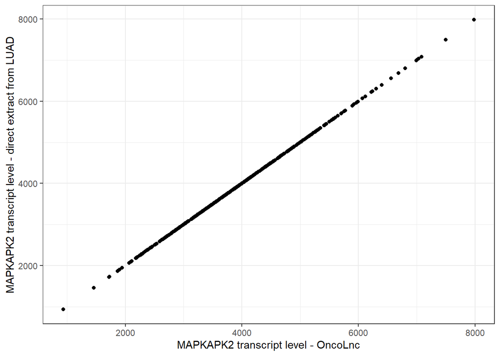

```r
library("DT")
library("TCGAbiolinks")
library(survival)
library(ggplot2)
library(ggpubr)
library(survminer)
library(knitr)
library("tidyr")
library("ggpmisc")

clinical <- GDCquery_clinic(project = "TCGA-LUAD", type = "clinical")
expr <- read.csv("../rawdata/LUAD.MAPKAPK2Exp.csv", header=TRUE)
colnames(expr) <- c("Patient", "MK2.Expression")
expr2 <- read.csv("../rawdata/LUAD.MAPKAPK2Exp.manual.csv", header=FALSE)
Casp3exp <- read.csv("../rawdata/LUAD.casp3Exp.2.csv")

colnames(expr2) <- c("MK2.Expression.Manual","Stage", "Patient")
expr2_normalcontrols <- expr2[grepl("11A", expr2$Patient),]
# take out normal controls
expr2 <- expr2[!grepl("11A", expr2$Patient),]

# remove non "01A" samples
expr3 <- expr2[grepl("01A", expr2$Patient),]
expr3$Patient <- substring(expr3$Patient, 1,12)
colnames(Casp3exp) <- c("Patient", "Casp3.Expression")
# the left_join. we need the clinical data, so we left_joined by TCGA patient id to the clinical dataset. This means that if there was a patient with clinical data without transcript levels, that would be a 'NA'.
clinical <- left_join(clinical, expr, c("submitter_id"= "Patient"))
clinical <- left_join(clinical, expr3, c("submitter_id" = "Patient"))
clinical <- left_join(clinical, Casp3exp, c("submitter_id"="Patient"))

ggplot(clinical, aes(x=MK2.Expression,y=MK2.Expression.Manual))+geom_point()+theme_bw()+ylab("MAPKAPK2 transcript level - direct extract from LUAD")+xlab("MAPKAPK2 transcript level - OncoLnc")
```

```r
clinical <- clinical[!is.na(clinical$vital_status),]
```

This shows that the correlation between MK2 Expression derived from OncoLnc and from TCGA is excellent. THus, we feel confident that the MK2 reads data from OncoLnc can be used going forward. This makes it easier to grab mRNA transcript levels for other genes directly from OncoLnc rather than having to extract it from TCGA via GDC.

## Clean the data, create a df for an LR and Cox PH analyses later

Now that we have left-joined the data, and checked to make sure that the join was done properly, we move on to prep the data for Cox PH work.

```r
clinical$time <- mapply(function(x,y) if(is.na(x)) return(y) else return(x), clinical$days_to_death, clinical$days_to_last_follow_up)
clinical$age_at_diagnosis <- clinical$age_at_diagnosis/365
clinical$race <- as.factor(clinical$race)
clinical$smoking <- lapply(clinical$cigarettes_per_day, function(x) if(!is.na(x)) return(1) else return(0))
clinical$tumor_stage <- as.factor(clinical$tumor_stage)
clinical$vital_status <- as.factor(clinical$vital_status)
clinical$status <- lapply(clinical$vital_status, function(x) if(x=="alive") return(0) else return(1))
clinical$smoking <- as.numeric(clinical$smoking)


# combine clinical stage

combineStage <- function(x) {
if(!is.na(x))  {
if(x=="Stage I" | x=="Stage IB" | x=="Stage IA") return("Early Stage")
if(x=="Stage II" | x=="Stage IIA" | x=="Stage IIB") return("Early Stage")
if(x=="Stage IIIA" | x=="Stage IIIB") return("Late Stage")
if(x=="Stage IV") return("Late Stage")
}
  }

# combined histologic types

combinePath <- function(x) {
 if(!is.na(x))  {

   if(x=="Adenocarcinoma, NOS") return("Adenocarcinoma")
   if(x=="Mucinous adenocarcinoma")  return("Adenocarcinoma")
   if(x=="Adenocarcinoma with mixed subtypes") return("Adenocarcinoma")
   if(x=="Papillary adenocarcinoma") return("Adenocarcinoma")
   else return("Non-Adenocarcinoma")

 }

}

# combine sub-stages into 1,2,3
clinical$ajcc_pathologic_stage_combined <- lapply(clinical$ajcc_pathologic_stage, combineStage)

clinical$ajcc_pathologic_stage_combined <- as.factor(as.character(clinical$ajcc_pathologic_stage_combined))

# combine histology types
clinical$primary_diagnosis_combined <- lapply(clinical$primary_diagnosis, combinePath)
clinical$primary_diagnosis_combined<- as.factor(unlist(clinical$primary_diagnosis_combined))

# get rid of NULL entries
clinical <- clinical[clinical$ajcc_pathologic_stage_combined!="NULL",]


# We already got rid of NULLs for ajcc_pathologic_stage. However, the factor levels still list 3 levels - early, late and NULL. To re-level, convert to character, re-convert to factor, and now only 2 levels.
clinical$ajcc_pathologic_stage_combined<-as.factor(as.character(clinical$ajcc_pathologic_stage_combined))

clinical <- clinical[!is.na(clinical$MK2.Expression), ]

# create censor variable for CoxPH
clinical$censor <- lapply(clinical$vital_status, function(x) if(x=="Alive") return(0) else return(1))
clinical$censor <- as.numeric(clinical$censor)

# scale the MK2 variable
clinical$MK2.Expression <- clinical$MK2.Expression/1000
clinical$MK2.Expression.Manual <- clinical$MK2.Expression.Manual/1000
clinical$Casp3.Expression <- clinical$Casp3.Expression/1000
# create a simplified stage

combineStage.Simp <- function(x) {
if(!is.na(x))  {
if(x=="Stage I" | x=="Stage IB" | x=="Stage IA") return("Stage 1")
if(x=="Stage II" | x=="Stage IIA" | x=="Stage IIB") return("Stage 2")
if(x=="Stage IIIA" | x=="Stage IIIB") return("Stage 3")
if(x=="Stage IV") return("Stage 4")
}
  }
clinical$ajcc_pathologic_stage_combined.2 <- lapply(clinical$ajcc_pathologic_stage, combineStage.Simp)
clinical$ajcc_pathologic_stage_combined.2 <- as.factor(unlist(clinical$ajcc_pathologic_stage_combined.2))
```

# Exploratory graphs

## Plot differences in transcript level by tumor histology and cancer stage

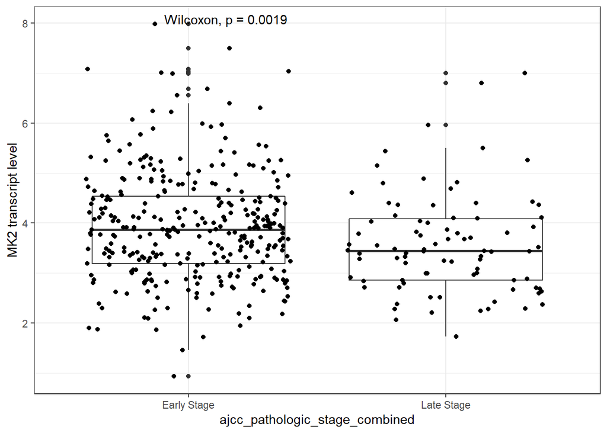

```r
# plot MK2 differences for adenocarcinoma only
ggplot(clinical[clinical$primary_diagnosis_combined=="Adenocarcinoma", ], aes(x=ajcc_pathologic_stage_combined, y=MK2.Expression, ))+geom_boxplot()+geom_point(position=position_jitter())+stat_compare_means()+theme_bw()+ylab("MK2 transcript level")
```

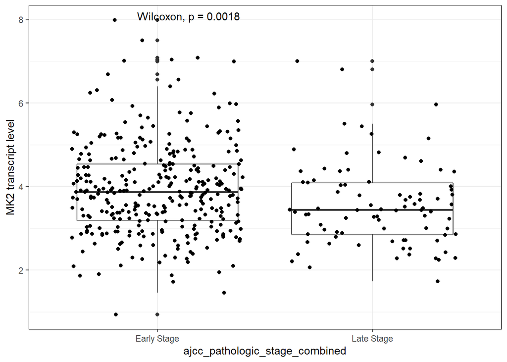

```r
ggplot(clinical[clinical$primary_diagnosis_combined=="Adenocarcinoma", ], aes(x=ajcc_pathologic_stage_combined, y=MK2.Expression.Manual, ))+geom_boxplot()+geom_point(position=position_jitter())+stat_compare_means()+theme_bw()+ylab("MK2 transcript level")
```

This is a key difference: MK2 is clearly associated with tumor stage. Early stage tumors have more MK2 transcript than late stage tumors. Thus, going forward, we will stratify our analyses by Tumor stage.

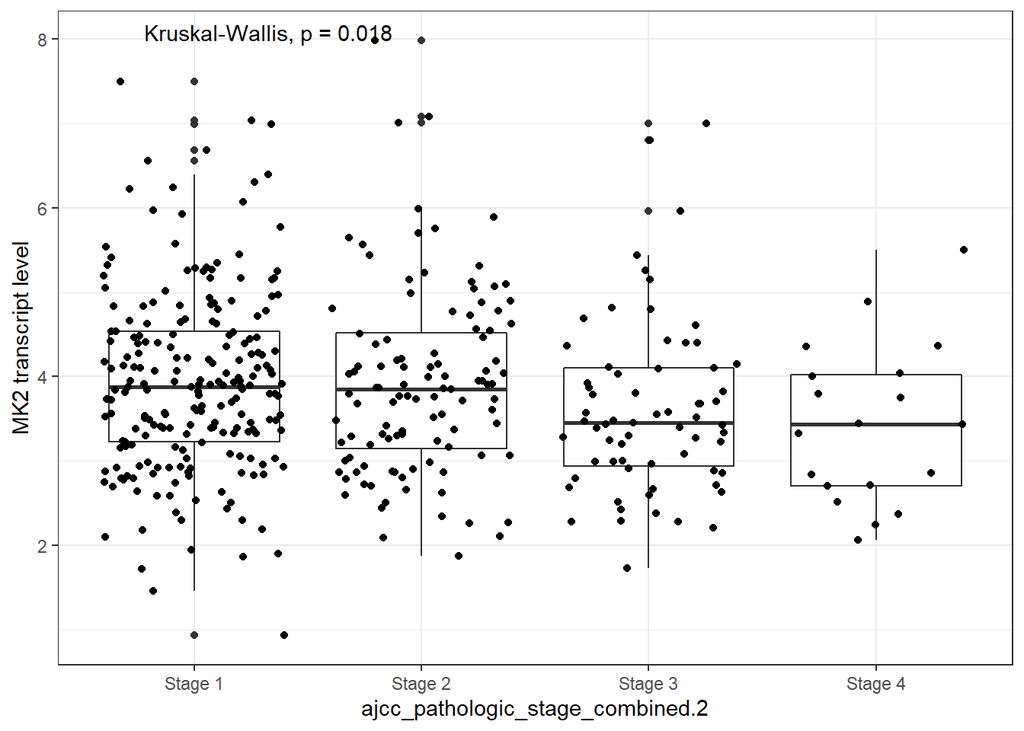

```r
ggplot(clinical[clinical$primary_diagnosis_combined=="Adenocarcinoma", ], aes(x=ajcc_pathologic_stage_combined.2, y=MK2.Expression, ))+geom_boxplot()+geom_point(position=position_jitter())+stat_compare_means()+theme_bw()+ylab("MK2 transcript level")
```

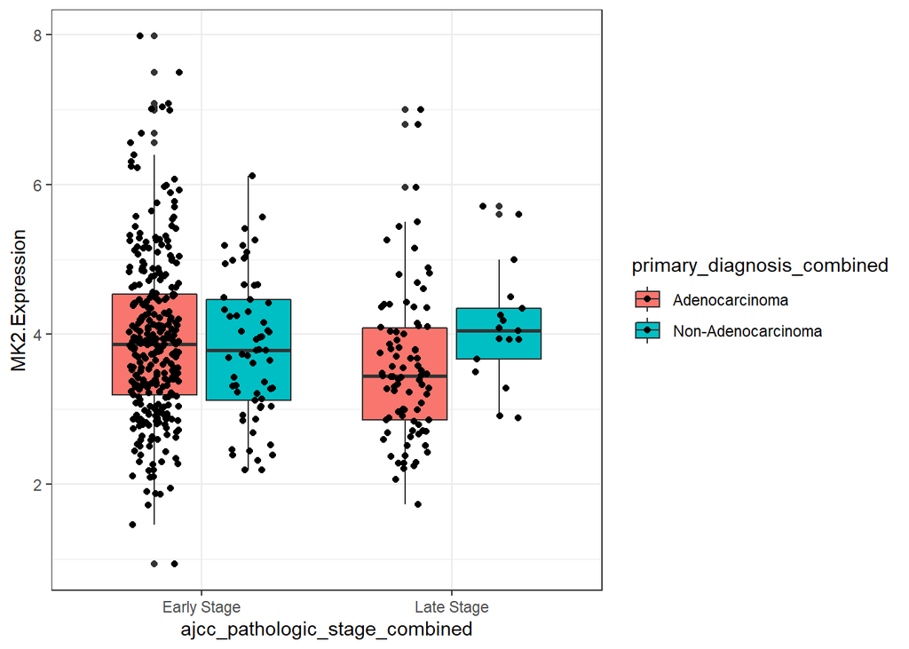

```r
ggplot(clinical, aes(x=ajcc_pathologic_stage_combined, y=MK2.Expression, fill=primary_diagnosis_combined))+geom_boxplot()+geom_point(position=position_jitterdodge())+theme_bw()
```

## Explore the relationship between MK2 and Casp3

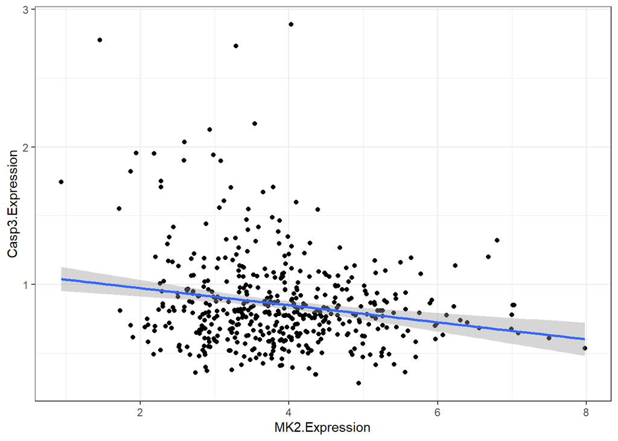

```r
ggplot(clinical, aes(x=MK2.Expression,y=Casp3.Expression)) + geom_point()+theme_bw()+geom_smooth(method="lm")
```

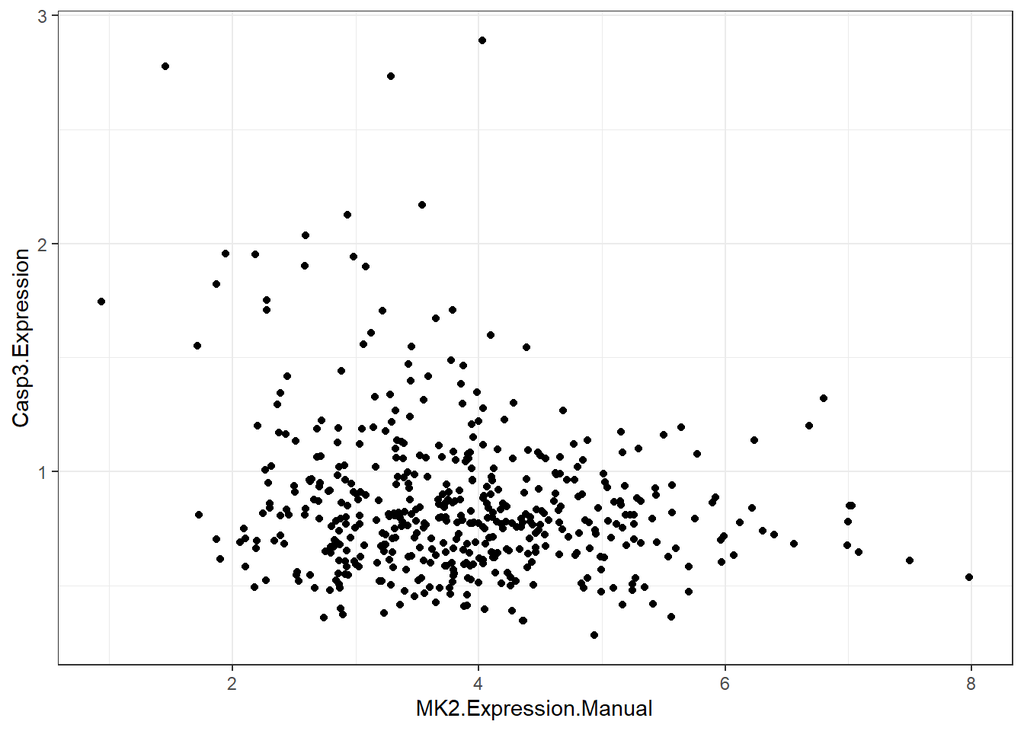

```r
ggplot(clinical, aes(x=MK2.Expression.Manual,y=Casp3.Expression)) + geom_point()+theme_bw()
```

We are technically able to “fit” a line through this data, but the relationship (i.e slope) is not particularly impressive. The raw data does not suggest any sort of linear relationship between Casp3 mRNA and MK2 mRNA levels.

## Defining MK2 thresholds for “high” and “low” - Top 1/3 vs Bottom 2/3

Mechanistically, we’re more interested in whether high vs. low MK2 transcript levels impact outcome. For this, we first categorize MK2 transcript levels based on quantiles and only take the lower and upper third in our groups for comparison.

```r
# classify the MK2 expression variable as either top or bottom quantile, based on quantile definitions

bottom_quant <<- 0.33
top_quant <<- 0.66

clinical$MK2_Expression_bottomQ <- lapply(clinical$MK2.Expression, function (x) if(x < quantile(clinical$MK2.Expression, bottom_quant))  return(1) else return(0))

clinical$MK2_Expression_topQ <- lapply(clinical$MK2.Expression, function (x) if(x > quantile(clinical$MK2.Expression, top_quant))  return(1) else return(0))
```

## Changes in proportion of people who died across quantiles of MK2

### Prep data for using MK2 quantiles

The (poorly named) MK2_CoxPH_quantile df is the df we’re using for all of our modeling purposes. This was originally used just for CoxPH, hence the name. We restrict this dataset to only those with follow-up available, and Adenocarcinomas only within LUAD. Additionally, we perform some more cleanup/create new variables as shown below.

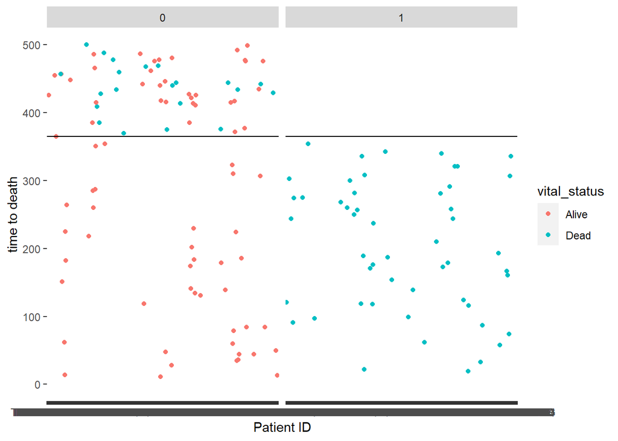

```r
# quantile and logistic regression

# this is the new data frame for this new round of calculations.
MK2_CoxPH_quantile <- clinical[!is.na(clinical$time) & clinical$primary_diagnosis_combined=="Adenocarcinoma",]

# this provides the variable for R censoring at one year and the outcome variable for logit regression.
MK2_CoxPH_quantile$death_at_1year <- mapply(function(dead,time) if(dead==1 & time <366) return(1) else if(dead==0 & time > 366) return(0) else if (dead==0 & time < 366) return(0) else if (dead==1 & time > 366) return(0), MK2_CoxPH_quantile$censor, as.numeric(MK2_CoxPH_quantile$time))

MK2_CoxPH_quantile$death_at_2year <- mapply(function(dead,time) if(dead==1 & time <366*2) return(1) else if(dead==0 & time > 366*2) return(0) else if (dead==0 & time < 366*2) return(0) else if (dead==1 & time > 366*2) return(0), MK2_CoxPH_quantile$censor, as.numeric(MK2_CoxPH_quantile$time))

MK2_CoxPH_quantile$death_at_3year <- mapply(function(dead,time) if(dead==1 & time <366*3) return(1) else if(dead==0 & time > 366*3) return(0) else if (dead==0 & time < 366*3) return(0) else if (dead==1 & time > 366*3) return(0), MK2_CoxPH_quantile$censor, as.numeric(MK2_CoxPH_quantile$time))

# this piece of code above is critical - so let's double check and make sure everything got done right

ggplot(MK2_CoxPH_quantile, aes(x=submitter_id, y=time, color=vital_status))+ geom_point()+facet_wrap(~death_at_1year)+ylim(0,500)+xlab("Patient ID") + ylab("time to death")+geom_hline(yintercept = 365)
```

Interpretation off the plot above. So, we have colored each patient’s vital status by alive or dead, and we have faceted by whether they were assigned as “Death in one year” or not. So, if our code worked, all patients who died in less than one year (blue color; y < 365) should be classified as dead at one year (“1”). All patients who were alive in that time period should be classified as red and in the “0” column. After 365 days, everyone should have gotten a classification of “0” for death at one year, since they are all by definition still alive at 1 year, regardless of subsequent alive or dead status (color should mix, all colors in the “0” column). And that’s what we see…

### Proportion of deaths by MK2 quantiles

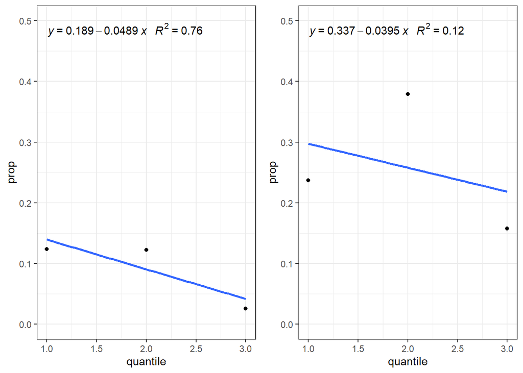

```r
#Now, moving on.

MK2_CoxPH_quantile$MK2_quantile <- ntile(MK2_CoxPH_quantile$MK2.Expression, 3)
MK2_CoxPH_quantile$Casp3_quantile  <- ntile(MK2_CoxPH_quantile$Casp3.Expression,3)
a <- aggregate(death_at_1year~MK2_quantile+ajcc_pathologic_stage_combined, FUN=sum, data=MK2_CoxPH_quantile)
b <- aggregate(death_at_1year~MK2_quantile+ajcc_pathologic_stage_combined, FUN=length, data=MK2_CoxPH_quantile)

quantile_df<-  as.data.frame(a$MK2_quantile)
quantile_df$stage <- as.data.frame(a$ajcc_pathologic_stage_combined)
quantile_df$prop <- as.data.frame(unlist(a$death_at_1year/b$death_at_1year))
quantile_df$prop <- unlist(quantile_df$prop)
colnames(quantile_df) <- c("quantile", "stage", "prop")
p1 <- ggplot(quantile_df[quantile_df$stage=="Early Stage",], aes(x=quantile, y=prop))+geom_point()+geom_smooth(method="lm", se=FALSE)+stat_poly_eq(formula="y~x", aes(label = paste(..eq.label.., ..rr.label.., sep = "~~~")), parse = TRUE)+theme_bw()+ylim(0,0.5)

p2 <- ggplot(quantile_df[quantile_df$stage=="Late Stage",], aes(x=quantile, y=prop))+geom_point()+geom_smooth(method="lm", se=FALSE)+stat_poly_eq(formula="y~x", aes(label = paste(..eq.label.., ..rr.label.., sep = "~~~")), parse = TRUE)+theme_bw()+ylim(0,0.5)

# This graph shows the relationship between MK2 quantile  and proportion of patients  who died in Early and Late Stage cancers. The relationship between MK2 quantile and Proportion of those patients  who died (denominator: all patients  in that quantile)
gridExtra::grid.arrange(p1,p2, ncol=2)
```

# Logistic regression modeling death at 1 year ~ MK2+covariates

## Data clean-up

```r
MK2_CoxPH_quantile$death_at_1year <- as.factor(MK2_CoxPH_quantile$death_at_1year)
# logistic regression and ROC
MK2_CoxPH_quantile$ajcc_pathologic_stage_early_stage <- unlist(MK2_CoxPH_quantile$ajcc_pathologic_stage_early_stage)
MK2_CoxPH_quantile$MK2_quantile <- as.factor(MK2_CoxPH_quantile$MK2_quantile)
MK2_CoxPH_quantile$MK2_Expression_topQ <- as.factor(unlist(MK2_CoxPH_quantile$MK2_Expression_topQ))
```

## Logistic regression for death at 1 year, stratified by early/late, MK2 as a continuous variable

### Univariate regression

```r
# LR stratified by Early/Late
summary(glm(death_at_1year ~ MK2.Expression, data=MK2_CoxPH_quantile[MK2_CoxPH_quantile$ajcc_pathologic_stage_combined=="Early Stage", ], family=binomial(link="logit")))
```

```
##
## Call:
## glm(formula = death_at_1year ~ MK2.Expression, family = binomial(link = "logit"),
##     data = MK2_CoxPH_quantile[MK2_CoxPH_quantile$ajcc_pathologic_stage_combined ==
##         "Early Stage", ])
##
## Deviance Residuals:
##     Min       1Q   Median       3Q      Max
## -0.7132  -0.4651  -0.4104  -0.3454   2.4882
##
## Coefficients:
##                Estimate Std. Error z value Pr(>|z|)
## (Intercept)     -0.8740     0.7590  -1.152   0.2495
## MK2.Expression  -0.3910     0.2041  -1.916   0.0554 .
## ---
## Signif. codes:  0 '***' 0.001 '**' 0.01 '*' 0.05 '.' 0.1 ' ' 1
##
## (Dispersion parameter for binomial family taken to be 1)
##
##     Null deviance: 189.71  on 318  degrees of freedom
## Residual deviance: 185.76  on 317  degrees of freedom
## AIC: 189.76
##
## Number of Fisher Scoring iterations: 5
```

```r
summary(glm(death_at_1year ~ MK2.Expression.Manual, data=MK2_CoxPH_quantile[MK2_CoxPH_quantile$ajcc_pathologic_stage_combined=="Early Stage", ], family=binomial(link="logit")))
```

```
##
## Call:
## glm(formula = death_at_1year ~ MK2.Expression.Manual, family = binomial(link = "logit"),
##     data = MK2_CoxPH_quantile[MK2_CoxPH_quantile$ajcc_pathologic_stage_combined ==
##         "Early Stage", ])
##
## Deviance Residuals:
##     Min       1Q   Median       3Q      Max
## -0.7151  -0.4664  -0.4106  -0.3458   2.4873
##
## Coefficients:
##                       Estimate Std. Error z value Pr(>|z|)
## (Intercept)            -0.8671     0.7581  -1.144   0.2527
## MK2.Expression.Manual  -0.3918     0.2038  -1.922   0.0546 .
## ---
## Signif. codes:  0 '***' 0.001 '**' 0.01 '*' 0.05 '.' 0.1 ' ' 1
##
## (Dispersion parameter for binomial family taken to be 1)
##
##     Null deviance: 189.53  on 317  degrees of freedom
## Residual deviance: 185.54  on 316  degrees of freedom
##   (1 observation deleted due to missingness)
## AIC: 189.54
##
## Number of Fisher Scoring iterations: 5
```

```r
# so you can see above that it doesn't matter which MK2 expression level you use - the point estimate is essentially the same

summary(glm(death_at_1year ~ MK2.Expression, data=MK2_CoxPH_quantile[MK2_CoxPH_quantile$ajcc_pathologic_stage_combined=="Late Stage", ], family=binomial(link="logit")))
```

```
##
## Call:
## glm(formula = death_at_1year ~ MK2.Expression, family = binomial(link = "logit"),
##     data = MK2_CoxPH_quantile[MK2_CoxPH_quantile$ajcc_pathologic_stage_combined ==
##         "Late Stage", ])
##
## Deviance Residuals:
##     Min       1Q   Median       3Q      Max
## -0.8449  -0.8022  -0.7821   1.5805   1.6744
##
## Coefficients:
##                Estimate Std. Error z value Pr(>|z|)
## (Intercept)    -0.69350    0.91543  -0.758    0.449
## MK2.Expression -0.08846    0.24994  -0.354    0.723
##
## (Dispersion parameter for binomial family taken to be 1)
##
##     Null deviance: 99.880  on 85  degrees of freedom
## Residual deviance: 99.753  on 84  degrees of freedom
## AIC: 103.75
##
## Number of Fisher Scoring iterations: 4
```

```r
summary(glm(death_at_1year ~ MK2.Expression.Manual, data=MK2_CoxPH_quantile[MK2_CoxPH_quantile$ajcc_pathologic_stage_combined=="Late Stage", ], family=binomial(link="logit")))
```

```
##
## Call:
## glm(formula = death_at_1year ~ MK2.Expression.Manual, family = binomial(link = "logit"),
##     data = MK2_CoxPH_quantile[MK2_CoxPH_quantile$ajcc_pathologic_stage_combined ==
##         "Late Stage", ])
##
## Deviance Residuals:
##     Min       1Q   Median       3Q      Max
## -0.8449  -0.8022  -0.7821   1.5805   1.6744
##
## Coefficients:
##                       Estimate Std. Error z value Pr(>|z|)
## (Intercept)           -0.69350    0.91543  -0.758    0.449
## MK2.Expression.Manual -0.08846    0.24994  -0.354    0.723
##
## (Dispersion parameter for binomial family taken to be 1)
##
##     Null deviance: 99.880  on 85  degrees of freedom
## Residual deviance: 99.753  on 84  degrees of freedom
## AIC: 103.75
##
## Number of Fisher Scoring iterations: 4
```

In this univariate regression, there is a suggestion of a negative association between MK2 (treated as a continuous variable) and death at one year, in the early stage patients. That is, higher MK2 = lower odds of death at one year. the CIs are imprecise, and thus the p values is 0.06. We do not see this in the late-stage patients.

As we noted in the code chunk itself, when we repeat the regressions using the manually derived expression data, the point estimates are essentially the same.

### Multivariate regression

```r
summary(glm(death_at_1year ~ MK2.Expression+smoking+age_at_diagnosis+gender, data=MK2_CoxPH_quantile[MK2_CoxPH_quantile$ajcc_pathologic_stage_combined=="Early Stage", ], family=binomial(link="logit")))
```

```
##
## Call:
## glm(formula = death_at_1year ~ MK2.Expression + smoking + age_at_diagnosis +
##     gender, family = binomial(link = "logit"), data = MK2_CoxPH_quantile[MK2_CoxPH_quantile$ajcc_pathologic_stage_combined ==
##     "Early Stage", ])
##
## Deviance Residuals:
##     Min       1Q   Median       3Q      Max
## -0.7519  -0.4579  -0.3556  -0.2933   2.5860
##
## Coefficients:
##                  Estimate Std. Error z value Pr(>|z|)
## (Intercept)      -1.01796    1.63391  -0.623   0.5333
## MK2.Expression   -0.32422    0.21042  -1.541   0.1234
## smoking           0.13949    0.49344   0.283   0.7774
## age_at_diagnosis -0.01141    0.02121  -0.538   0.5906
## gendermale        0.82992    0.43657   1.901   0.0573 .
## ---
## Signif. codes:  0 '***' 0.001 '**' 0.01 '*' 0.05 '.' 0.1 ' ' 1
##
## (Dispersion parameter for binomial family taken to be 1)
##
##     Null deviance: 174.15  on 311  degrees of freedom
## Residual deviance: 166.81  on 307  degrees of freedom
##   (7 observations deleted due to missingness)
## AIC: 176.81
##
## Number of Fisher Scoring iterations: 5
```

```r
summary(glm(death_at_1year ~ MK2.Expression.Manual+smoking+age_at_diagnosis+gender, data=MK2_CoxPH_quantile[MK2_CoxPH_quantile$ajcc_pathologic_stage_combined=="Early Stage", ], family=binomial(link="logit")))
```

```
##
## Call:
## glm(formula = death_at_1year ~ MK2.Expression.Manual + smoking +
##     age_at_diagnosis + gender, family = binomial(link = "logit"),
##     data = MK2_CoxPH_quantile[MK2_CoxPH_quantile$ajcc_pathologic_stage_combined ==
##         "Early Stage", ])
##
## Deviance Residuals:
##     Min       1Q   Median       3Q      Max
## -0.7532  -0.4580  -0.3560  -0.2940   2.5831
##
## Coefficients:
##                       Estimate Std. Error z value Pr(>|z|)
## (Intercept)           -1.00486    1.63248  -0.616   0.5382
## MK2.Expression.Manual -0.32499    0.21024  -1.546   0.1221
## smoking                0.14350    0.49345   0.291   0.7712
## age_at_diagnosis      -0.01149    0.02118  -0.543   0.5874
## gendermale             0.82207    0.43670   1.882   0.0598 .
## ---
## Signif. codes:  0 '***' 0.001 '**' 0.01 '*' 0.05 '.' 0.1 ' ' 1
##
## (Dispersion parameter for binomial family taken to be 1)
##
##     Null deviance: 173.98  on 310  degrees of freedom
## Residual deviance: 166.67  on 306  degrees of freedom
##   (8 observations deleted due to missingness)
## AIC: 176.67
##
## Number of Fisher Scoring iterations: 5
```

```r
summary(glm(death_at_1year ~ MK2.Expression+smoking+age_at_diagnosis+gender, data=MK2_CoxPH_quantile[MK2_CoxPH_quantile$ajcc_pathologic_stage_combined=="Late Stage", ], family=binomial(link="logit")))
```

```
##
## Call:
## glm(formula = death_at_1year ~ MK2.Expression + smoking + age_at_diagnosis +
##     gender, family = binomial(link = "logit"), data = MK2_CoxPH_quantile[MK2_CoxPH_quantile$ajcc_pathologic_stage_combined ==
##     "Late Stage", ])
##
## Deviance Residuals:
##     Min       1Q   Median       3Q      Max
## -1.1177  -0.8219  -0.7066   1.4406   1.9247
##
## Coefficients:
##                  Estimate Std. Error z value Pr(>|z|)
## (Intercept)      -2.64865    1.98157  -1.337    0.181
## MK2.Expression   -0.06162    0.26183  -0.235    0.814
## smoking          -0.42478    0.51632  -0.823    0.411
## age_at_diagnosis  0.03072    0.02594   1.184    0.236
## gendermale        0.33048    0.49610   0.666    0.505
##
## (Dispersion parameter for binomial family taken to be 1)
##
##     Null deviance: 99.880  on 85  degrees of freedom
## Residual deviance: 97.263  on 81  degrees of freedom
## AIC: 107.26
##
## Number of Fisher Scoring iterations: 4
```

## Model 2 in paper: Logistic regression for death at 1 year, stratified by early/late, but using Top 1/3 MK2 expression (dichotomous MK2 variable)

### Model 2: MK2 only

```r
logreg_topq1_early <- glm(death_at_1year ~ MK2_Expression_topQ+smoking+age_at_diagnosis+gender, data=MK2_CoxPH_quantile[MK2_CoxPH_quantile$ajcc_pathologic_stage_combined=="Early Stage", ], family=binomial(link="logit"))


summary(logreg_topq1_early)
```

```
##
## Call:
## glm(formula = death_at_1year ~ MK2_Expression_topQ + smoking +
##     age_at_diagnosis + gender, family = binomial(link = "logit"),
##     data = MK2_CoxPH_quantile[MK2_CoxPH_quantile$ajcc_pathologic_stage_combined ==
##         "Early Stage", ])
##
## Deviance Residuals:
##     Min       1Q   Median       3Q      Max
## -0.7059  -0.4897  -0.3689  -0.2019   2.8548
##
## Coefficients:
##                      Estimate Std. Error z value Pr(>|z|)
## (Intercept)          -1.62809    1.47184  -1.106   0.2687
## MK2_Expression_topQ1 -1.50091    0.63011  -2.382   0.0172 *
## smoking               0.16785    0.49734   0.337   0.7357
## age_at_diagnosis     -0.01533    0.02089  -0.734   0.4629
## gendermale            0.78866    0.43959   1.794   0.0728 .
## ---
## Signif. codes:  0 '***' 0.001 '**' 0.01 '*' 0.05 '.' 0.1 ' ' 1
##
## (Dispersion parameter for binomial family taken to be 1)
##
##     Null deviance: 174.15  on 311  degrees of freedom
## Residual deviance: 161.58  on 307  degrees of freedom
##   (7 observations deleted due to missingness)
## AIC: 171.58
##
## Number of Fisher Scoring iterations: 6
```

```r
exp(logreg_topq1_early$coefficients)
```

```
##          (Intercept) MK2_Expression_topQ1              smoking
##            0.1963034            0.2229281            1.1827597
##     age_at_diagnosis           gendermale
##            0.9847829            2.2004382
```

```r
exp(confint.lm(logreg_topq1_early))
```

```
##                           2.5 %    97.5 %
## (Intercept)          0.01084259 3.5540422
## MK2_Expression_topQ1 0.06451920 0.7702661
## smoking              0.44451696 3.1470578
## age_at_diagnosis     0.94512249 1.0261075
## gendermale           0.92651066 5.2259825
```

```r
logreg_topq1_late <- glm(death_at_1year ~ MK2_Expression_topQ+smoking+age_at_diagnosis+gender, data=MK2_CoxPH_quantile[MK2_CoxPH_quantile$ajcc_pathologic_stage_combined=="Late Stage", ], family=binomial(link="logit"))

summary(logreg_topq1_late)
```

```
##
## Call:
## glm(formula = death_at_1year ~ MK2_Expression_topQ + smoking +
##     age_at_diagnosis + gender, family = binomial(link = "logit"),
##     data = MK2_CoxPH_quantile[MK2_CoxPH_quantile$ajcc_pathologic_stage_combined ==
##         "Late Stage", ])
##
## Deviance Residuals:
##     Min       1Q   Median       3Q      Max
## -1.1548  -0.8278  -0.6714   1.3897   2.1483
##
## Coefficients:
##                      Estimate Std. Error z value Pr(>|z|)
## (Intercept)          -2.63173    1.80098  -1.461    0.144
## MK2_Expression_topQ1 -0.72657    0.69371  -1.047    0.295
## smoking              -0.38921    0.51949  -0.749    0.454
## age_at_diagnosis      0.02873    0.02663   1.079    0.281
## gendermale            0.33859    0.49884   0.679    0.497
##
## (Dispersion parameter for binomial family taken to be 1)
##
##     Null deviance: 99.880  on 85  degrees of freedom
## Residual deviance: 96.109  on 81  degrees of freedom
## AIC: 106.11
##
## Number of Fisher Scoring iterations: 4
```

```r
exp(logreg_topq1_late$coefficients)
```

```
##          (Intercept) MK2_Expression_topQ1              smoking
##           0.07195393           0.48356425           0.67759368
##     age_at_diagnosis           gendermale
##           1.02914235           1.40296293
```

```r
exp(confint.lm(logreg_topq1_late))
```

```
##                            2.5 %   97.5 %
## (Intercept)          0.001998996 2.589984
## MK2_Expression_topQ1 0.121623019 1.922616
## smoking              0.241030494 1.904876
## age_at_diagnosis     0.976038424 1.085136
## gendermale           0.519985525 3.785307
```

### Model 2: MK2 multivariate model with Casp3

Now we run the multi-variate model again but with casp3 expression

```r
summary(glm(death_at_1year ~ MK2_Expression_topQ+smoking+age_at_diagnosis+gender+Casp3.Expression, data=MK2_CoxPH_quantile[MK2_CoxPH_quantile$ajcc_pathologic_stage_combined=="Early Stage", ], family=binomial(link="logit")))
```

```
##
## Call:
## glm(formula = death_at_1year ~ MK2_Expression_topQ + smoking +
##     age_at_diagnosis + gender + Casp3.Expression, family = binomial(link = "logit"),
##     data = MK2_CoxPH_quantile[MK2_CoxPH_quantile$ajcc_pathologic_stage_combined ==
##         "Early Stage", ])
##
## Deviance Residuals:
##     Min       1Q   Median       3Q      Max
## -0.7254  -0.4847  -0.3644  -0.2027   2.8681
##
## Coefficients:
##                      Estimate Std. Error z value Pr(>|z|)
## (Intercept)          -1.83073    1.55821  -1.175   0.2400
## MK2_Expression_topQ1 -1.48182    0.63241  -2.343   0.0191 *
## smoking               0.16960    0.49755   0.341   0.7332
## age_at_diagnosis     -0.01550    0.02089  -0.742   0.4581
## gendermale            0.79744    0.44050   1.810   0.0703 .
## Casp3.Expression      0.23193    0.58747   0.395   0.6930
## ---
## Signif. codes:  0 '***' 0.001 '**' 0.01 '*' 0.05 '.' 0.1 ' ' 1
##
## (Dispersion parameter for binomial family taken to be 1)
##
##     Null deviance: 174.15  on 311  degrees of freedom
## Residual deviance: 161.43  on 306  degrees of freedom
##   (7 observations deleted due to missingness)
## AIC: 173.43
##
## Number of Fisher Scoring iterations: 6
```

# Cox Proportional Hazards modeling, with right censoring at 1 year.

## Data Cleaning

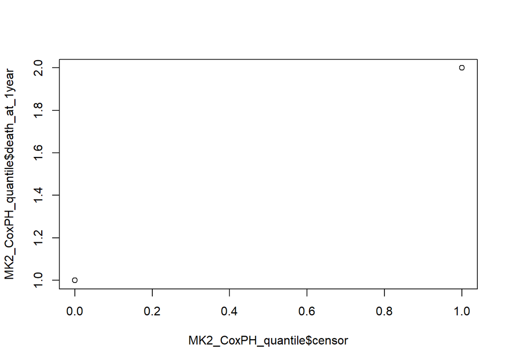

```r
# data cleaning prior to Cox PH model
MK2_CoxPH_quantile$MK2_Expression_topQ <- as.factor(unlist(MK2_CoxPH_quantile$MK2_Expression_topQ))
MK2_CoxPH_quantile$gender <- as.factor(MK2_CoxPH_quantile$gender)

# be careful here. as.numeric alone will return the factor level, not the value!
MK2_CoxPH_quantile$censor <- as.numeric(as.character(MK2_CoxPH_quantile$death_at_1year))
MK2_CoxPH_quantile$censor.2y <- as.numeric(as.character(MK2_CoxPH_quantile$death_at_2year))
MK2_CoxPH_quantile$censor.3y <- as.numeric(as.character(MK2_CoxPH_quantile$death_at_3year))

# there should be no discrepancy - only two dots should show up
plot(MK2_CoxPH_quantile$censor, MK2_CoxPH_quantile$death_at_1year)
```

## Cox PH model R censored at one year, stratified by early/late, MK2 as a continuous variable

### Model 1: MK2 only

```r
# univariate Cox PH
summary(coxph(Surv(time, censor) ~ MK2.Expression, id=submitter_id, data=MK2_CoxPH_quantile[MK2_CoxPH_quantile$ajcc_pathologic_stage_combined=="Early Stage",]))
```

```
## Call:
## coxph(formula = Surv(time, censor) ~ MK2.Expression, data = MK2_CoxPH_quantile[MK2_CoxPH_quantile$ajcc_pathologic_stage_combined ==
##     "Early Stage", ], id = submitter_id)
##
##   n= 319, number of events= 28
##
##                   coef exp(coef) se(coef)      z Pr(>|z|)
## MK2.Expression -0.3488    0.7055   0.1930 -1.808   0.0707 .
## ---
## Signif. codes:  0 '***' 0.001 '**' 0.01 '*' 0.05 '.' 0.1 ' ' 1
##
##                exp(coef) exp(-coef) lower .95 upper .95
## MK2.Expression    0.7055      1.417    0.4833      1.03
##
## Concordance= 0.606  (se = 0.046 )
## Likelihood ratio test= 3.45  on 1 df,   p=0.06
## Wald test            = 3.27  on 1 df,   p=0.07
## Score (logrank) test = 3.25  on 1 df,   p=0.07
```

```r
# Multi-variate Cox PH
MK2_coxph_model_tb_1y_early <- coxph(Surv(time, censor) ~ MK2.Expression+gender+smoking+age_at_diagnosis, id=submitter_id, data=MK2_CoxPH_quantile[MK2_CoxPH_quantile$ajcc_pathologic_stage_combined=="Early Stage",])

MK2_coxph_model_tb_1y_late <- coxph(Surv(time, censor) ~ MK2.Expression+gender+smoking+age_at_diagnosis, id=submitter_id, data=MK2_CoxPH_quantile[MK2_CoxPH_quantile$ajcc_pathologic_stage_combined=="Late Stage",])


# PH testing
cox.zph(MK2_coxph_model_tb_1y_early)
```

```
##                  chisq df    p
## MK2.Expression   1.522  1 0.22
## gender           0.419  1 0.52
## smoking          3.276  1 0.07
## age_at_diagnosis 1.616  1 0.20
## GLOBAL           6.371  4 0.17
```

```r
cox.zph(MK2_coxph_model_tb_1y_late)
```

```
##                   chisq df    p
## MK2.Expression   0.3655  1 0.55
## gender           1.2832  1 0.26
## smoking          0.2681  1 0.60
## age_at_diagnosis 0.0349  1 0.85
## GLOBAL           1.9921  4 0.74
```

```r
# results
summary(MK2_coxph_model_tb_1y_early)
```

```
## Call:
## coxph(formula = Surv(time, censor) ~ MK2.Expression + gender +
##     smoking + age_at_diagnosis, data = MK2_CoxPH_quantile[MK2_CoxPH_quantile$ajcc_pathologic_stage_combined ==
##     "Early Stage", ], id = submitter_id)
##
##   n= 312, number of events= 25
##    (7 observations deleted due to missingness)
##
##                      coef exp(coef) se(coef)      z Pr(>|z|)
## MK2.Expression   -0.27510   0.75949  0.19775 -1.391   0.1642
## gendermale        0.83411   2.30276  0.41878  1.992   0.0464 *
## smoking           0.06909   1.07153  0.47106  0.147   0.8834
## age_at_diagnosis -0.01332   0.98676  0.02050 -0.650   0.5158
## ---
## Signif. codes:  0 '***' 0.001 '**' 0.01 '*' 0.05 '.' 0.1 ' ' 1
##
##                  exp(coef) exp(-coef) lower .95 upper .95
## MK2.Expression      0.7595     1.3167    0.5155     1.119
## gendermale          2.3028     0.4343    1.0134     5.233
## smoking             1.0715     0.9332    0.4256     2.698
## age_at_diagnosis    0.9868     1.0134    0.9479     1.027
##
## Concordance= 0.644  (se = 0.058 )
## Likelihood ratio test= 7.33  on 4 df,   p=0.1
## Wald test            = 7.09  on 4 df,   p=0.1
## Score (logrank) test = 7.36  on 4 df,   p=0.1
```

```r
summary(MK2_coxph_model_tb_1y_late)
```

```
## Call:
## coxph(formula = Surv(time, censor) ~ MK2.Expression + gender +
##     smoking + age_at_diagnosis, data = MK2_CoxPH_quantile[MK2_CoxPH_quantile$ajcc_pathologic_stage_combined ==
##     "Late Stage", ], id = submitter_id)
##
##   n= 86, number of events= 23
##
##                      coef exp(coef) se(coef)      z Pr(>|z|)
## MK2.Expression   -0.07991   0.92320  0.21887 -0.365    0.715
## gendermale        0.20038   1.22187  0.41969  0.477    0.633
## smoking          -0.24635   0.78165  0.43026 -0.573    0.567
## age_at_diagnosis  0.02883   1.02925  0.02252  1.280    0.201
##
##                  exp(coef) exp(-coef) lower .95 upper .95
## MK2.Expression      0.9232     1.0832    0.6012     1.418
## gendermale          1.2219     0.8184    0.5368     2.781
## smoking             0.7817     1.2793    0.3363     1.817
## age_at_diagnosis    1.0293     0.9716    0.9848     1.076
##
## Concordance= 0.601  (se = 0.058 )
## Likelihood ratio test= 2.58  on 4 df,   p=0.6
## Wald test            = 2.39  on 4 df,   p=0.7
## Score (logrank) test = 2.43  on 4 df,   p=0.7
```

So here, we can see that in multi-variate Cox PH model, we see a signal for MK2 and improved survival, but only in the early stage tumors.

### MK2 with casp 3

```r
summary(coxph(Surv(time, censor) ~ MK2.Expression+gender+smoking+age_at_diagnosis+Casp3.Expression, id=submitter_id, data=MK2_CoxPH_quantile[MK2_CoxPH_quantile$ajcc_pathologic_stage_combined=="Early Stage",]))
```

```
## Call:
## coxph(formula = Surv(time, censor) ~ MK2.Expression + gender +
##     smoking + age_at_diagnosis + Casp3.Expression, data = MK2_CoxPH_quantile[MK2_CoxPH_quantile$ajcc_pathologic_stage_combined ==
##     "Early Stage", ], id = submitter_id)
##
##   n= 312, number of events= 25
##    (7 observations deleted due to missingness)
##
##                      coef exp(coef) se(coef)      z Pr(>|z|)
## MK2.Expression   -0.25541   0.77460  0.20031 -1.275   0.2023
## gendermale        0.84606   2.33045  0.41925  2.018   0.0436 *
## smoking           0.07316   1.07591  0.47159  0.155   0.8767
## age_at_diagnosis -0.01301   0.98707  0.02050 -0.635   0.5256
## Casp3.Expression  0.30076   1.35089  0.58307  0.516   0.6060
## ---
## Signif. codes:  0 '***' 0.001 '**' 0.01 '*' 0.05 '.' 0.1 ' ' 1
##
##                  exp(coef) exp(-coef) lower .95 upper .95
## MK2.Expression      0.7746     1.2910    0.5231     1.147
## gendermale          2.3305     0.4291    1.0247     5.300
## smoking             1.0759     0.9294    0.4269     2.711
## age_at_diagnosis    0.9871     1.0131    0.9482     1.028
## Casp3.Expression    1.3509     0.7403    0.4308     4.236
##
## Concordance= 0.646  (se = 0.059 )
## Likelihood ratio test= 7.58  on 5 df,   p=0.2
## Wald test            = 7.38  on 5 df,   p=0.2
## Score (logrank) test = 7.67  on 5 df,   p=0.2
```

## Model 1 in paper: Cox PH model R censored at one year, stratified by early late, MK2 as dichotomous (top 1/3 vs. bottom 2/3)

### Model 1: MK2 only

```r
summary(coxph(Surv(time, censor) ~ MK2_Expression_topQ+gender+smoking+age_at_diagnosis, id=submitter_id, data=MK2_CoxPH_quantile[MK2_CoxPH_quantile$ajcc_pathologic_stage_combined=="Early Stage",]))
```

```
## Call:
## coxph(formula = Surv(time, censor) ~ MK2_Expression_topQ + gender +
##     smoking + age_at_diagnosis, data = MK2_CoxPH_quantile[MK2_CoxPH_quantile$ajcc_pathologic_stage_combined ==
##     "Early Stage", ], id = submitter_id)
##
##   n= 312, number of events= 25
##    (7 observations deleted due to missingness)
##
##                          coef exp(coef) se(coef)      z Pr(>|z|)
## MK2_Expression_topQ1 -1.42504   0.24050  0.61622 -2.313   0.0207 *
## gendermale            0.81309   2.25486  0.41812  1.945   0.0518 .
## smoking               0.06489   1.06704  0.47247  0.137   0.8908
## age_at_diagnosis     -0.01696   0.98318  0.02001 -0.848   0.3966
## ---
## Signif. codes:  0 '***' 0.001 '**' 0.01 '*' 0.05 '.' 0.1 ' ' 1
##
##                      exp(coef) exp(-coef) lower .95 upper .95
## MK2_Expression_topQ1    0.2405     4.1580   0.07188    0.8047
## gendermale              2.2549     0.4435   0.99361    5.1171
## smoking                 1.0670     0.9372   0.42268    2.6937
## age_at_diagnosis        0.9832     1.0171   0.94536    1.0225
##
## Concordance= 0.701  (se = 0.053 )
## Likelihood ratio test= 12.76  on 4 df,   p=0.01
## Wald test            = 10.18  on 4 df,   p=0.04
## Score (logrank) test = 11.53  on 4 df,   p=0.02
```

```r
summary(coxph(Surv(time, censor) ~ MK2_Expression_topQ+gender+smoking+age_at_diagnosis, id=submitter_id, data=MK2_CoxPH_quantile[MK2_CoxPH_quantile$ajcc_pathologic_stage_combined=="Late Stage",]))
```

```
## Call:
## coxph(formula = Surv(time, censor) ~ MK2_Expression_topQ + gender +
##     smoking + age_at_diagnosis, data = MK2_CoxPH_quantile[MK2_CoxPH_quantile$ajcc_pathologic_stage_combined ==
##     "Late Stage", ], id = submitter_id)
##
##   n= 86, number of events= 23
##
##                          coef exp(coef) se(coef)      z Pr(>|z|)
## MK2_Expression_topQ1 -0.71417   0.48960  0.62288 -1.147    0.252
## gendermale            0.19689   1.21761  0.41857  0.470    0.638
## smoking              -0.20205   0.81705  0.43065 -0.469    0.639
## age_at_diagnosis      0.02776   1.02815  0.02282  1.217    0.224
##
##                      exp(coef) exp(-coef) lower .95 upper .95
## MK2_Expression_topQ1    0.4896     2.0425    0.1444     1.660
## gendermale              1.2176     0.8213    0.5361     2.766
## smoking                 0.8171     1.2239    0.3513     1.900
## age_at_diagnosis        1.0281     0.9726    0.9832     1.075
##
## Concordance= 0.626  (se = 0.058 )
## Likelihood ratio test= 4  on 4 df,   p=0.4
## Wald test            = 3.51  on 4 df,   p=0.5
## Score (logrank) test = 3.6  on 4 df,   p=0.5
```

### Model 1: MK2 + casp3

```r
summary(coxph(Surv(time, censor) ~ MK2_Expression_topQ+gender+smoking+age_at_diagnosis+Casp3.Expression, id=submitter_id, data=MK2_CoxPH_quantile[MK2_CoxPH_quantile$ajcc_pathologic_stage_combined=="Early Stage",]))
```

```
## Call:
## coxph(formula = Surv(time, censor) ~ MK2_Expression_topQ + gender +
##     smoking + age_at_diagnosis + Casp3.Expression, data = MK2_CoxPH_quantile[MK2_CoxPH_quantile$ajcc_pathologic_stage_combined ==
##     "Early Stage", ], id = submitter_id)
##
##   n= 312, number of events= 25
##    (7 observations deleted due to missingness)
##
##                          coef exp(coef) se(coef)      z Pr(>|z|)
## MK2_Expression_topQ1 -1.40534   0.24528  0.61767 -2.275   0.0229 *
## gendermale            0.82233   2.27580  0.41871  1.964   0.0495 *
## smoking               0.07424   1.07707  0.47357  0.157   0.8754
## age_at_diagnosis     -0.01664   0.98350  0.01999 -0.832   0.4051
## Casp3.Expression      0.30803   1.36074  0.56469  0.545   0.5854
## ---
## Signif. codes:  0 '***' 0.001 '**' 0.01 '*' 0.05 '.' 0.1 ' ' 1
##
##                      exp(coef) exp(-coef) lower .95 upper .95
## MK2_Expression_topQ1    0.2453     4.0769    0.0731    0.8231
## gendermale              2.2758     0.4394    1.0017    5.1706
## smoking                 1.0771     0.9284    0.4257    2.7248
## age_at_diagnosis        0.9835     1.0168    0.9457    1.0228
## Casp3.Expression        1.3607     0.7349    0.4499    4.1157
##
## Concordance= 0.707  (se = 0.054 )
## Likelihood ratio test= 13.04  on 5 df,   p=0.02
## Wald test            = 10.5  on 5 df,   p=0.06
## Score (logrank) test = 11.81  on 5 df,   p=0.04
```

# Model Graphics

## KM curve - here, we’re going to stratify MK2 by “hi” vs. “low” - Model 1

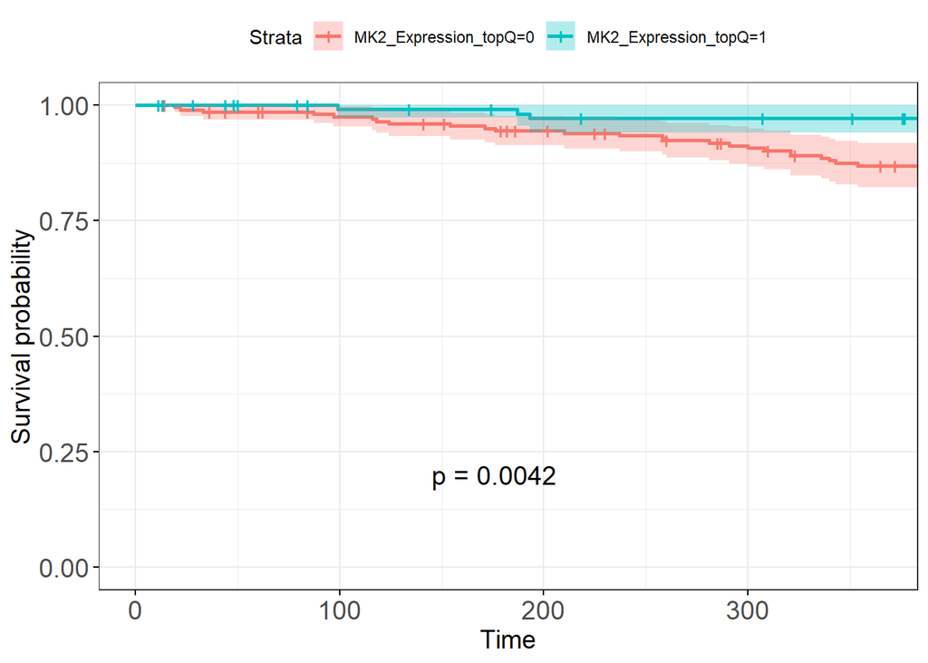

```r
library(survminer)
library(survival)
library(ggsci)
km_early <- survfit(Surv(time, censor)~MK2_Expression_topQ, data=MK2_CoxPH_quantile[MK2_CoxPH_quantile$ajcc_pathologic_stage_combined=="Early Stage",], type='kaplan-meier')
ggsurvplot(km_early, xlim=c(0,365), conf.int = TRUE, break.x.by=100, pval=TRUE, font.y=14,font.x=14,font.tickslab=14, ggtheme=theme_bw())
```

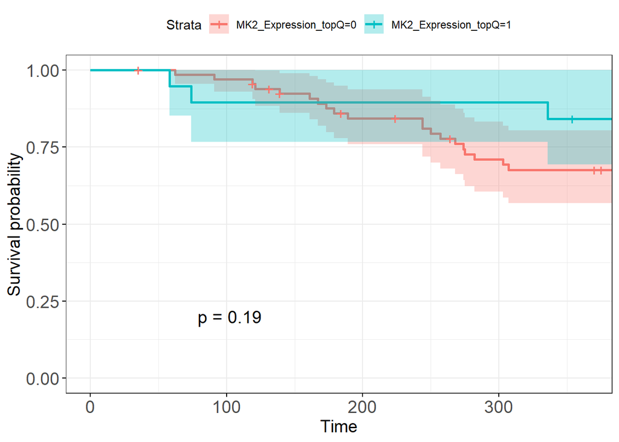

```r
km_late <- survfit(Surv(time, censor)~MK2_Expression_topQ, data=MK2_CoxPH_quantile[MK2_CoxPH_quantile$ajcc_pathologic_stage_combined=="Late Stage",], type='kaplan-meier')
ggsurvplot(km_late, xlim=c(0,365), conf.int = TRUE, break.x.by=100, pval=TRUE, font.y=14,font.x=14,font.tickslab=14, ggtheme=theme_bw())
```

## Predicted probabilities graphs for Logistic Regression (Model 2)

```r
library(effects)
```

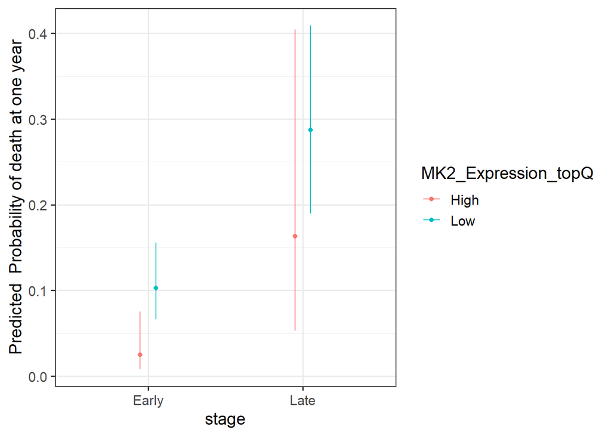

```r
library(ggthemes)
MK2efx_early <- Effect("MK2_Expression_topQ", logreg_topq1_early)
MK2efx_late <- Effect("MK2_Expression_topQ", logreg_topq1_late)

MK2efx_early <- as.data.frame(MK2efx_early)
MK2efx_late <- as.data.frame(MK2efx_late)
MK2efx_early$stage <- "Early"
MK2efx_late$stage <- "Late"
MK2efx <- rbind(MK2efx_early, MK2efx_late)
MK2efx$MK2_Expression_topQ <- lapply(MK2efx$MK2_Expression_topQ, function(x) if (x==0) return("Low") else return("High"))
MK2efx$MK2_Expression_topQ <- as.factor(unlist(MK2efx$MK2_Expression_topQ))
ggplot(MK2efx, aes(x=stage, y=fit, group=MK2_Expression_topQ, color=MK2_Expression_topQ, ymin=lower,ymax=upper))+geom_point(position=position_dodge(width=0.2))+geom_errorbar(width=0, position=position_dodge(width=0.2))+theme_bw(base_size = 14)+ylab("Predicted  Probability of death at one year")
```

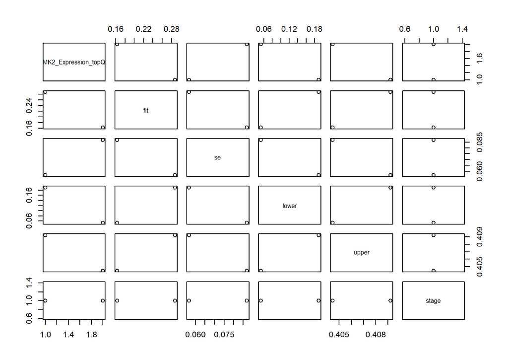

```r
p1 <- plot(MK2efx_late)
```

# Demographics / Table 1

```r
library(tableone)
listVars <- c("age_at_diagnosis", "gender", "smoking", "ajcc_pathologic_stage","ajcc_pathologic_n", "prior_malignancy", "primary_diagnosis", "time", "race", "MK2.Expression")
catVars <- c("gender", "smoking", "ajcc_pathologic_stage", "ajcc_pathologic_n", "prior_malignancy", "primary_diagnosis", "race")

table1 <- CreateTableOne(listVars, clinical, catVars, strata=c("ajcc_pathologic_stage_combined"), addOverall=TRUE)
table1
```

```
##                                                 Stratified by ajcc_pathologic_stage_combined
##                                                  Overall
##   n                                                 483
##   age_at_diagnosis (mean (SD))                    65.77 (9.97)
##   gender = male (%)                                 219 (45.3)
##   smoking = 1 (%)                                   331 (68.5)
##   ajcc_pathologic_stage (%)
##      Stage I                                          5 ( 1.0)
##      Stage IA                                       129 (26.7)
##      Stage IB                                       128 (26.5)
##      Stage II                                         1 ( 0.2)
##      Stage IIA                                       50 (10.4)
##      Stage IIB                                       67 (13.9)
##      Stage IIIA                                      69 (14.3)
##      Stage IIIB                                      10 ( 2.1)
##      Stage IV                                        24 ( 5.0)
##   ajcc_pathologic_n (%)
##      N0                                             313 (64.8)
##      N1                                              90 (18.6)
##      N2                                              68 (14.1)
##      N3                                               2 ( 0.4)
##      NX                                              10 ( 2.1)
##   prior_malignancy = yes (%)                         79 (16.4)
##   primary_diagnosis (%)
##      Acinar cell carcinoma                           22 ( 4.6)
##      Adenocarcinoma with mixed subtypes             103 (21.3)
##      Adenocarcinoma, NOS                            289 (59.8)
##      Bronchio-alveolar carcinoma, mucinous            5 ( 1.0)
##      Bronchiolo-alveolar adenocarcinoma, NOS          3 ( 0.6)
##      Bronchiolo-alveolar carcinoma, non-mucinous     17 ( 3.5)
##      Clear cell adenocarcinoma, NOS                   2 ( 0.4)
##      Micropapillary carcinoma, NOS                    2 ( 0.4)
##      Mucinous adenocarcinoma                         13 ( 2.7)
##      Papillary adenocarcinoma, NOS                   21 ( 4.3)
##      Signet ring cell carcinoma                       1 ( 0.2)
##      Solid carcinoma, NOS                             5 ( 1.0)
##   time (mean (SD))                               879.55 (873.37)
##   race (%)
##      american indian or alaska native                 1 ( 0.2)
##      asian                                            8 ( 1.7)
```

[output cut: 77 more lines]

```
##      Bronchiolo-alveolar carcinoma, non-mucinous      4 ( 3.9)
##      Clear cell adenocarcinoma, NOS                   1 ( 1.0)
##      Micropapillary carcinoma, NOS                    0 ( 0.0)
##      Mucinous adenocarcinoma                          1 ( 1.0)
##      Papillary adenocarcinoma, NOS                    6 ( 5.8)
##      Signet ring cell carcinoma                       0 ( 0.0)
##      Solid carcinoma, NOS                             0 ( 0.0)
##   time (mean (SD))                               696.95 (636.03)  0.017
##   race (%)                                                        0.449
##      american indian or alaska native                 0 ( 0.0)
##      asian                                            2 ( 1.9)
##      black or african american                        9 ( 8.7)
##      not reported                                    14 (13.6)
##      white                                           78 (75.7)
##   MK2.Expression (mean (SD))                       3.66 (0.99)    0.032
```

# Additional models and analysis

In this model, we use MK2 expression as a continuous variable - in other words, don’t split into low vs. high (for that, see below). The ‘MK.Expression’ variable is the MK2 transcript level. Here, we’re going to use the full follow-up time without any R censoring.

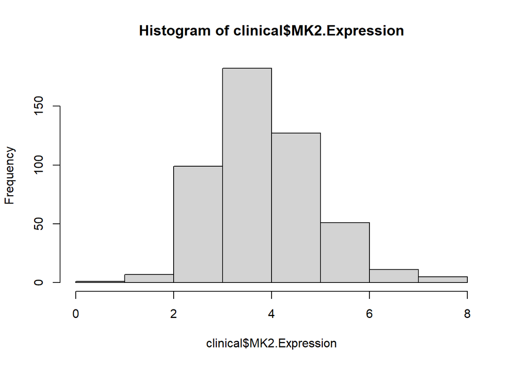

```r
# COX PH model
coxph_model_all <- coxph(Surv(time, censor) ~ MK2.Expression, id=submitter_id, data=clinical[clinical$ajcc_pathologic_stage_combined.2=="Stage 1",])


# examine MK2 expression values
hist(clinical$MK2.Expression)
```

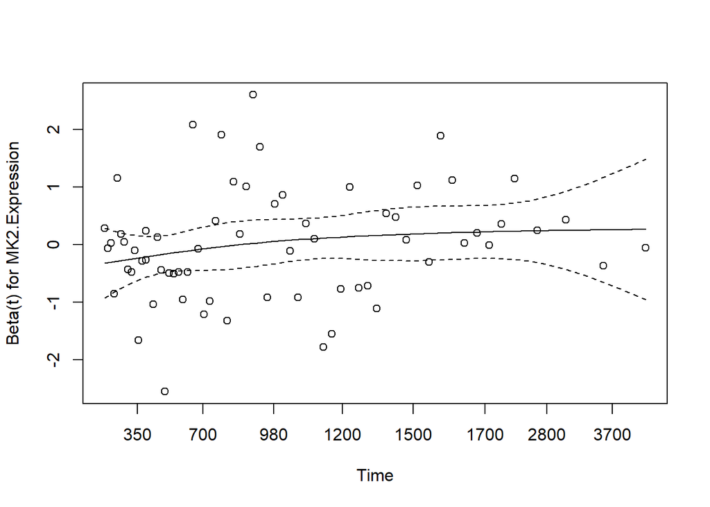

```r
plot(cox.zph(coxph_model_all))
```

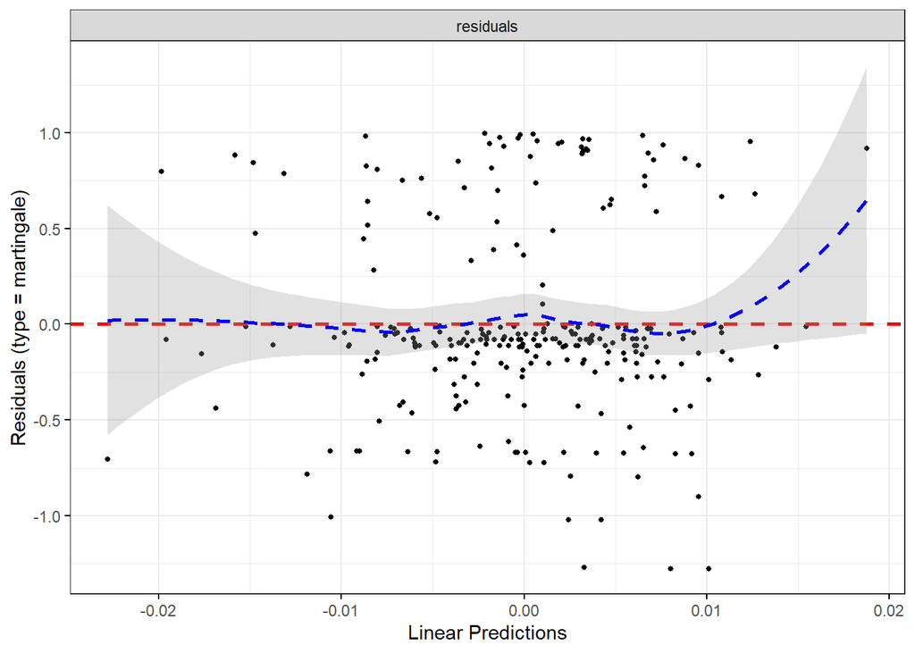

```r
ggcoxdiagnostics(coxph_model_all)
```

These diagnostic plots aren’t promising, and there we are really interested in early survival. Biologically, it makes more sense to focus on 1 year survival since 2- and 3- year survival may be related to a lot of other factors (including chemo regimens recieved, etc)

## Logistic regression for death at 1 year, stratified by specific stage

As shown above, LR using MK2 as a continuous variable but tumor stage dichotomized as early/late produced some interesting results. We wondered if we were “overlumping” stage by combining Stage I and II into “Early Stage”. Here we split stages into 1-4. Of course, now the problem was low numbers. These models did not yield any additional information, so were not considered further.

```r
# LR stratified by individual stage
summary(glm(death_at_1year ~ MK2.Expression, data=MK2_CoxPH_quantile[MK2_CoxPH_quantile$ajcc_pathologic_stage_combined.2=="Stage 1", ], family=binomial(link="logit")))
```

```
##
## Call:
## glm(formula = death_at_1year ~ MK2.Expression, family = binomial(link = "logit"),
##     data = MK2_CoxPH_quantile[MK2_CoxPH_quantile$ajcc_pathologic_stage_combined.2 ==
##         "Stage 1", ])
##
## Deviance Residuals:
##     Min       1Q   Median       3Q      Max
## -0.4456  -0.3181  -0.2899  -0.2583   2.6770
##
## Coefficients:
##                Estimate Std. Error z value Pr(>|z|)
## (Intercept)     -1.9805     1.2743  -1.554    0.120
## MK2.Expression  -0.2988     0.3375  -0.885    0.376
##
## (Dispersion parameter for binomial family taken to be 1)
##
##     Null deviance: 74.394  on 210  degrees of freedom
## Residual deviance: 73.576  on 209  degrees of freedom
## AIC: 77.576
##
## Number of Fisher Scoring iterations: 6
```

```r
summary(glm(death_at_1year ~ MK2.Expression, data=MK2_CoxPH_quantile[MK2_CoxPH_quantile$ajcc_pathologic_stage_combined.2=="Stage 2", ], family=binomial(link="logit")))
```

```
##
## Call:
## glm(formula = death_at_1year ~ MK2.Expression, family = binomial(link = "logit"),
##     data = MK2_CoxPH_quantile[MK2_CoxPH_quantile$ajcc_pathologic_stage_combined.2 ==
##         "Stage 2", ])
##
## Deviance Residuals:
##     Min       1Q   Median       3Q      Max
## -0.9166  -0.6776  -0.5733  -0.4215   2.2349
##
## Coefficients:
##                Estimate Std. Error z value Pr(>|z|)
## (Intercept)      0.2439     1.0268   0.238   0.8123
## MK2.Expression  -0.4773     0.2768  -1.724   0.0846 .
## ---
## Signif. codes:  0 '***' 0.001 '**' 0.01 '*' 0.05 '.' 0.1 ' ' 1
##
## (Dispersion parameter for binomial family taken to be 1)
##
##     Null deviance: 100.47  on 107  degrees of freedom
## Residual deviance:  97.09  on 106  degrees of freedom
## AIC: 101.09
##
## Number of Fisher Scoring iterations: 4
```

```r
summary(glm(death_at_1year ~ MK2.Expression, data=MK2_CoxPH_quantile[MK2_CoxPH_quantile$ajcc_pathologic_stage_combined.2=="Stage 3", ], family=binomial(link="logit")))
```

```
##
## Call:
## glm(formula = death_at_1year ~ MK2.Expression, family = binomial(link = "logit"),
##     data = MK2_CoxPH_quantile[MK2_CoxPH_quantile$ajcc_pathologic_stage_combined.2 ==
##         "Stage 3", ])
##
## Deviance Residuals:
##     Min       1Q   Median       3Q      Max
## -1.0027  -0.8448  -0.7861   1.4666   1.7445
##
## Coefficients:
##                Estimate Std. Error z value Pr(>|z|)
## (Intercept)     0.05054    1.05892   0.048    0.962
## MK2.Expression -0.27542    0.29351  -0.938    0.348
##
## (Dispersion parameter for binomial family taken to be 1)
##
##     Null deviance: 79.905  on 66  degrees of freedom
## Residual deviance: 78.958  on 65  degrees of freedom
## AIC: 82.958
##
## Number of Fisher Scoring iterations: 4
```

```r
summary(glm(death_at_1year ~ MK2.Expression, data=MK2_CoxPH_quantile[MK2_CoxPH_quantile$ajcc_pathologic_stage_combined.2=="Stage 4", ], family=binomial(link="logit")))
```

```
##
## Call:
## glm(formula = death_at_1year ~ MK2.Expression, family = binomial(link = "logit"),
##     data = MK2_CoxPH_quantile[MK2_CoxPH_quantile$ajcc_pathologic_stage_combined.2 ==
##         "Stage 4", ])
##
## Deviance Residuals:
##     Min       1Q   Median       3Q      Max
## -1.1913  -0.6872  -0.5152  -0.4273   1.8134
##
## Coefficients:
##                Estimate Std. Error z value Pr(>|z|)
## (Intercept)     -3.8831     2.4529  -1.583    0.113
## MK2.Expression   0.7118     0.6355   1.120    0.263
##
## (Dispersion parameter for binomial family taken to be 1)
##
##     Null deviance: 19.557  on 18  degrees of freedom
## Residual deviance: 18.216  on 17  degrees of freedom
## AIC: 22.216
##
## Number of Fisher Scoring iterations: 4
```

```r
summary(glm(death_at_1year ~ MK2_Expression_topQ, data=MK2_CoxPH_quantile[MK2_CoxPH_quantile$ajcc_pathologic_stage_combined.2=="Stage 1", ], family=binomial(link="logit")))
```

```
##
## Call:
## glm(formula = death_at_1year ~ MK2_Expression_topQ, family = binomial(link = "logit"),
##     data = MK2_CoxPH_quantile[MK2_CoxPH_quantile$ajcc_pathologic_stage_combined.2 ==
##         "Stage 1", ])
##
## Deviance Residuals:
##     Min       1Q   Median       3Q      Max
## -0.3550  -0.3550  -0.3550  -0.1586   2.9604
##
## Coefficients:
##                      Estimate Std. Error z value Pr(>|z|)
## (Intercept)           -2.7327     0.3649  -7.490 6.91e-14 ***
## MK2_Expression_topQ1  -1.6367     1.0704  -1.529    0.126
## ---
## Signif. codes:  0 '***' 0.001 '**' 0.01 '*' 0.05 '.' 0.1 ' ' 1
##
## (Dispersion parameter for binomial family taken to be 1)
##
##     Null deviance: 74.394  on 210  degrees of freedom
## Residual deviance: 70.985  on 209  degrees of freedom
## AIC: 74.985
##
## Number of Fisher Scoring iterations: 7
```

```r
summary(glm(death_at_1year ~ MK2_Expression_topQ, data=MK2_CoxPH_quantile[MK2_CoxPH_quantile$ajcc_pathologic_stage_combined.2=="Stage 2", ], family=binomial(link="logit")))
```

```
##
## Call:
## glm(formula = death_at_1year ~ MK2_Expression_topQ, family = binomial(link = "logit"),
##     data = MK2_CoxPH_quantile[MK2_CoxPH_quantile$ajcc_pathologic_stage_combined.2 ==
##         "Stage 2", ])
##
## Deviance Residuals:
##     Min       1Q   Median       3Q      Max
## -0.7339  -0.7339  -0.7339  -0.3381   2.4043
##
## Coefficients:
##                      Estimate Std. Error z value Pr(>|z|)
## (Intercept)           -1.1741     0.2775  -4.231 2.33e-05 ***
## MK2_Expression_topQ1  -1.6591     0.7787  -2.131   0.0331 *
## ---
## Signif. codes:  0 '***' 0.001 '**' 0.01 '*' 0.05 '.' 0.1 ' ' 1
##
## (Dispersion parameter for binomial family taken to be 1)
##
##     Null deviance: 100.474  on 107  degrees of freedom
## Residual deviance:  94.152  on 106  degrees of freedom
## AIC: 98.152
##
## Number of Fisher Scoring iterations: 5
```

```r
summary(glm(death_at_1year ~ MK2_Expression_topQ, data=MK2_CoxPH_quantile[MK2_CoxPH_quantile$ajcc_pathologic_stage_combined.2=="Stage 3", ], family=binomial(link="logit")))
```

```
##
## Call:
## glm(formula = death_at_1year ~ MK2_Expression_topQ, family = binomial(link = "logit"),
##     data = MK2_CoxPH_quantile[MK2_CoxPH_quantile$ajcc_pathologic_stage_combined.2 ==
##         "Stage 3", ])
##
## Deviance Residuals:
##     Min       1Q   Median       3Q      Max
## -0.8898  -0.8898  -0.8898   1.4953   2.0074
##
## Coefficients:
##                      Estimate Std. Error z value Pr(>|z|)
## (Intercept)           -0.7221     0.2956  -2.443   0.0146 *
## MK2_Expression_topQ1  -1.1497     0.8151  -1.411   0.1584
## ---
## Signif. codes:  0 '***' 0.001 '**' 0.01 '*' 0.05 '.' 0.1 ' ' 1
##
## (Dispersion parameter for binomial family taken to be 1)
##
##     Null deviance: 79.905  on 66  degrees of freedom
## Residual deviance: 77.506  on 65  degrees of freedom
## AIC: 81.506
##
## Number of Fisher Scoring iterations: 4
```

```r
summary(glm(death_at_1year ~ MK2_Expression_topQ, data=MK2_CoxPH_quantile[MK2_CoxPH_quantile$ajcc_pathologic_stage_combined.2=="Stage 4", ], family=binomial(link="logit")))
```

```
##
## Call:
## glm(formula = death_at_1year ~ MK2_Expression_topQ, family = binomial(link = "logit"),
##     data = MK2_CoxPH_quantile[MK2_CoxPH_quantile$ajcc_pathologic_stage_combined.2 ==
##         "Stage 4", ])
##
## Deviance Residuals:
##     Min       1Q   Median       3Q      Max
## -0.7585  -0.6681  -0.6681  -0.6681   1.7941
##
## Coefficients:
##                      Estimate Std. Error z value Pr(>|z|)
## (Intercept)           -1.3863     0.6455  -2.148   0.0317 *
## MK2_Expression_topQ1   0.2877     1.3229   0.217   0.8278
## ---
## Signif. codes:  0 '***' 0.001 '**' 0.01 '*' 0.05 '.' 0.1 ' ' 1
##
## (Dispersion parameter for binomial family taken to be 1)
##
##     Null deviance: 19.557  on 18  degrees of freedom
## Residual deviance: 19.511  on 17  degrees of freedom
## AIC: 23.511
##
## Number of Fisher Scoring iterations: 4
```

```r
summary(glm(death_at_1year ~ MK2_Expression_topQ, data=MK2_CoxPH_quantile[MK2_CoxPH_quantile$ajcc_pathologic_stage_combined.2=="Stage 1", ], family=binomial(link="logit")))
```

```
##
## Call:
## glm(formula = death_at_1year ~ MK2_Expression_topQ, family = binomial(link = "logit"),
##     data = MK2_CoxPH_quantile[MK2_CoxPH_quantile$ajcc_pathologic_stage_combined.2 ==
##         "Stage 1", ])
##
## Deviance Residuals:
##     Min       1Q   Median       3Q      Max
## -0.3550  -0.3550  -0.3550  -0.1586   2.9604
##
## Coefficients:
##                      Estimate Std. Error z value Pr(>|z|)
## (Intercept)           -2.7327     0.3649  -7.490 6.91e-14 ***
## MK2_Expression_topQ1  -1.6367     1.0704  -1.529    0.126
## ---
## Signif. codes:  0 '***' 0.001 '**' 0.01 '*' 0.05 '.' 0.1 ' ' 1
##
## (Dispersion parameter for binomial family taken to be 1)
##
##     Null deviance: 74.394  on 210  degrees of freedom
## Residual deviance: 70.985  on 209  degrees of freedom
## AIC: 74.985
##
## Number of Fisher Scoring iterations: 7
```

```r
summary(glm(death_at_1year ~ MK2_Expression_topQ, data=MK2_CoxPH_quantile[MK2_CoxPH_quantile$ajcc_pathologic_stage_combined.2=="Stage 2", ], family=binomial(link="logit")))
```

```
##
## Call:
## glm(formula = death_at_1year ~ MK2_Expression_topQ, family = binomial(link = "logit"),
##     data = MK2_CoxPH_quantile[MK2_CoxPH_quantile$ajcc_pathologic_stage_combined.2 ==
##         "Stage 2", ])
##
## Deviance Residuals:
##     Min       1Q   Median       3Q      Max
## -0.7339  -0.7339  -0.7339  -0.3381   2.4043
##
## Coefficients:
##                      Estimate Std. Error z value Pr(>|z|)
## (Intercept)           -1.1741     0.2775  -4.231 2.33e-05 ***
## MK2_Expression_topQ1  -1.6591     0.7787  -2.131   0.0331 *
## ---
## Signif. codes:  0 '***' 0.001 '**' 0.01 '*' 0.05 '.' 0.1 ' ' 1
##
## (Dispersion parameter for binomial family taken to be 1)
##
##     Null deviance: 100.474  on 107  degrees of freedom
## Residual deviance:  94.152  on 106  degrees of freedom
## AIC: 98.152
##
## Number of Fisher Scoring iterations: 5
```

```r
summary(glm(death_at_1year ~ MK2_Expression_topQ, data=MK2_CoxPH_quantile[MK2_CoxPH_quantile$ajcc_pathologic_stage_combined.2=="Stage 3", ], family=binomial(link="logit")))
```

```
##
## Call:
## glm(formula = death_at_1year ~ MK2_Expression_topQ, family = binomial(link = "logit"),
##     data = MK2_CoxPH_quantile[MK2_CoxPH_quantile$ajcc_pathologic_stage_combined.2 ==
##         "Stage 3", ])
##
## Deviance Residuals:
##     Min       1Q   Median       3Q      Max
## -0.8898  -0.8898  -0.8898   1.4953   2.0074
##
## Coefficients:
##                      Estimate Std. Error z value Pr(>|z|)
## (Intercept)           -0.7221     0.2956  -2.443   0.0146 *
## MK2_Expression_topQ1  -1.1497     0.8151  -1.411   0.1584
## ---
## Signif. codes:  0 '***' 0.001 '**' 0.01 '*' 0.05 '.' 0.1 ' ' 1
##
## (Dispersion parameter for binomial family taken to be 1)
##
##     Null deviance: 79.905  on 66  degrees of freedom
## Residual deviance: 77.506  on 65  degrees of freedom
## AIC: 81.506
##
## Number of Fisher Scoring iterations: 4
```

```r
summary(glm(death_at_1year ~ MK2_Expression_topQ, data=MK2_CoxPH_quantile[MK2_CoxPH_quantile$ajcc_pathologic_stage_combined.2=="Stage 4", ], family=binomial(link="logit")))
```

```
##
## Call:
## glm(formula = death_at_1year ~ MK2_Expression_topQ, family = binomial(link = "logit"),
##     data = MK2_CoxPH_quantile[MK2_CoxPH_quantile$ajcc_pathologic_stage_combined.2 ==
##         "Stage 4", ])
##
## Deviance Residuals:
##     Min       1Q   Median       3Q      Max
## -0.7585  -0.6681  -0.6681  -0.6681   1.7941
##
## Coefficients:
##                      Estimate Std. Error z value Pr(>|z|)
## (Intercept)           -1.3863     0.6455  -2.148   0.0317 *
## MK2_Expression_topQ1   0.2877     1.3229   0.217   0.8278
## ---
## Signif. codes:  0 '***' 0.001 '**' 0.01 '*' 0.05 '.' 0.1 ' ' 1
##
## (Dispersion parameter for binomial family taken to be 1)
##
##     Null deviance: 19.557  on 18  degrees of freedom
## Residual deviance: 19.511  on 17  degrees of freedom
## AIC: 23.511
##
## Number of Fisher Scoring iterations: 4
```

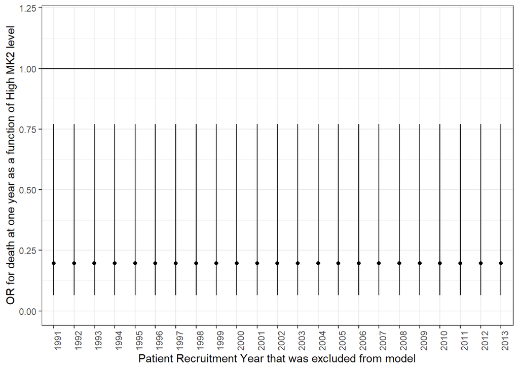

```r
MK2_tvary <- MK2_CoxPH_quantile
years <- as.data.frame(table(as.factor(as.character(clinical$year_of_diagnosis))))
MK2_tvary$year_of_diagnosis <- as.factor(as.character(MK2_tvary$year_of_diagnosis))


returnPointEst <- function(x) {
   modelresult <- glm(death_at_1year ~ MK2_Expression_topQ+smoking+age_at_diagnosis+gender, data=MK2_CoxPH_quantile[MK2_CoxPH_quantile$ajcc_pathologic_stage_combined=="Early Stage", ], family=binomial(link="logit"))
   return(exp(modelresult$coefficients[1]))
}

years$estimate <- lapply(as.character(years$Var1), returnPointEst)
years$estimate <- lapply(years$estimate, function(x) return(x[[1]]))

returnPointEstlci <- function(x) {
    modelresult <- glm(death_at_1year ~ MK2_Expression_topQ+smoking+age_at_diagnosis+gender, data=MK2_CoxPH_quantile[MK2_CoxPH_quantile$ajcc_pathologic_stage_combined=="Early Stage", ], family=binomial(link="logit"))
   return(exp(confint.lm(modelresult)[2]))
}

returnPointEstuci <- function(x) {
     modelresult <- glm(death_at_1year ~ MK2_Expression_topQ+smoking+age_at_diagnosis+gender, data=MK2_CoxPH_quantile[MK2_CoxPH_quantile$ajcc_pathologic_stage_combined=="Early Stage", ], family=binomial(link="logit"))
   return(exp(confint.lm(modelresult)[7]))
}


years$estimate_lci <- lapply(as.character(years$Var1), returnPointEstlci)
years$estimate_uci <- lapply(as.character(years$Var1), returnPointEstuci)

years$estimate <- as.numeric(years$estimate)
years$estimate_lci<- as.numeric(years$estimate_lci)
years$estimate_uci <- as.numeric(years$estimate_uci)

ggplot(years, aes(x=Var1, y=estimate))+geom_point()+geom_errorbar(aes(ymin=estimate_lci, ymax=estimate_uci), width=0)+theme_bw()+ylim(0,1.2)+geom_hline(yintercept = 1)+ylab("OR for death at one year as a function of High MK2 level")+xlab("Patient Recruitment Year that was excluded from model")+theme(axis.text.x = element_text(angle = 90, hjust = 1))
```

# Normal vs. tumor tissue

One of the benefits of downloading data from the TCGA is that it includes the “11” barcode, which is normal tissue

```r
expr2_normalcontrols$Patient <- substring(expr2_normalcontrols$Patient,1,12)
expr2_normalcontrols$sample.type="Normal Tissue"
expr2_t <- expr3
expr2_t$sample.type="Tumor"

exp2_paired <- left_join(expr2_normalcontrols, expr2_t, by=c("Patient"))
exp2_paired <-exp2_paired[!is.na(exp2_paired$MK2.Expression.Manual.y),]
exp2_paired
```

```
##    MK2.Expression.Manual.x     Stage.x      Patient sample.type.x
## 1                 3627.927 Early Stage TCGA-55-6983 Normal Tissue
## 2                 2965.097 Early Stage TCGA-50-5932 Normal Tissue
## 3                 4425.499 Early Stage TCGA-50-5931 Normal Tissue
## 4                 3236.439 Early Stage TCGA-44-6778 Normal Tissue
## 5                 2926.808 Early Stage TCGA-91-6836 Normal Tissue
## 7                 3490.549 Early Stage TCGA-55-6975 Normal Tissue
## 8                 2975.724 Early Stage TCGA-55-6980 Normal Tissue
## 9                 3322.967 Early Stage TCGA-38-4625 Normal Tissue
## 10                8434.913 Early Stage TCGA-44-6147 Normal Tissue
## 11                3255.905 Early Stage TCGA-55-6972 Normal Tissue
## 12                2785.330 Early Stage TCGA-49-6744 Normal Tissue
## 13                2602.993 Early Stage TCGA-55-6985 Normal Tissue
## 14                4520.906 Early Stage TCGA-44-2665 Normal Tissue
## 15                3461.315 Early Stage TCGA-55-6979 Normal Tissue
```

[output cut: 99 more lines]

```r
# These data are plotted elsewhere.
```